# Can we predict S&P500 Returns Using Non-Price Information?

14 April 2016

## Background

- The S&P 500 is a widely followed equity index and benchmarks in the US
- There are many ways to trade the S&P
- Futures, options and other derivatives
- Exchange traded funds (e.g. SPY)
- Investment funds
- Those different markets publish public information about various investors' positions
- **Can we use this information and various forecasting models to predict future returns and create profits better than through simple models?**

## Overview of the dataset

## Which data will we use?

- *Price information*: Price and volume of the SPDR ETF (SPY)
- *CBOE Index put and call volume* - volume of put and call options traded on equity indices (more call options = bullish, put options = bearish)
- *Commitment of trader report (COT)* - Every week reports number of long and short future contracts held by:
- Large speculators - investment funds and hedge funds ('smart money')
- Commercials - investment banks, brokers and market makers
- Others - Speculators below the reporting threshold
- **The weekly change in investors' net positions could hold clues as to future market direction**

## How do variables evolve over time?

[figure not shown]

- 2008 crash and subsequent recovery evident in the chart
- No obvious linear correlation between different SPY price and non-price variables
- **Price series is non-stationary so we will look at predicting returns**

## What do S&P500 returns between 2006 and 2016 look like?

[figure not shown]

- Mean and median slightly positive but close to 0%
- Fat tails evident:
- Extreme of c.-20% once
- A few occurences >10%
- **Simple benchmark would be to assume returns equal to mean returns**

## Overview of the models

## Forecasting and comparison methodology

- The models are trained on a training set, between November 2006 and November 2012
- The fitted models are then used to forecast weekly returns in a test period from the end of the training period to March 2016
- Difference between predicted and actual returns in the forecast period allows us to gauge accuracy
- We can compare the models by looking at their **root mean squared errors - RMSE** (the square root of the average deviation between fitted values and actual values) in the test period
- **The lower the RMSE in the test period, the better the fit**

## Models tested

- We'll look at the following algorithms:
- Benchmark model 1 - returns equal mean returns
- Benmark model 2 - returns equal the most recent returns
- Multiple linear regression
- Regression trees
- Random forest
- The models were chosen due to their ability to take into account multiple variables and to find non-linear relationships

## Benchmark models

### Models to beat

## Benchmark model 1 - Average approach

- The average approach predicts that all future returns equal the mean return of the training set (+0.08%)
- Given the distribution of returns, this could be a reasonably good prediction of future returns

[figure not shown]

- The chart shows a good fit both in the training and test periods
- The RMSE in the test period for the average approach is c.1.69

## Benchmark model 2 - Naive approach

- The naive approach simply assumes that returns at time *t+1* equal current returns at time *t*
- If changes in returns are persistent, this could be a good approximation

[figure not shown]

- The RMSE for the naive approach in the test period is c.2.5, and the chart shows the fit is not particularly good

## Models to test

## Linear Regression

- The linear regression model attempts to find a relationship between returns and the various non-price variables (in addition to the previous week's returns)
- The results of the regression suggested that only the following variables were important: **Previous % return, change in net put colume, and the change in the put-call ratio** so only those variables were kept
- However, the multiple R^2 for the equation is only c.1.97%, suggesting that the variables chosen do not explain much of the variation in returns

[figure not shown]

- The RMSE for multiple linear regression in the test period is c.1.8, better than the naive but worse than the average approach

## Regression Tree

- The regression tree model creates a decision tree which fits the training set subject to a complexity parameter (which can be adjusted order to avoid overfitting) that determines the number of nodes for the decision tree
- **The complexity parameter suggested by the model as minimising cross-validated error is none, and would yield the average model**. However, to see whether choosing a tree with five splits is better than the naive model
- The following shows the decision tree model fitted to the training set

[figure not shown]

## Regression Tree - cont.

[figure not shown]

- The RMSE for the regression tree model is c.1.95, which is worse than all but the naive approach

## Random Forest

- The random forest algorithm creates a large number of decision trees and chooses the mean predicted return from those individual trees to improve accuracy vs. a standard regression tree and improving the latter's tendency towards overfitting
- The random forest algorithm was run with 5,000 trees
- The following chart shows the different features' importance according to the algorithm:

[figure not shown]

## Random Forest - cont.

[figure not shown]

- The RMSE for the random forest algorithm is c1.88, which is better than the regression tree algorithm but does not improve on the other models

## Model Comparison

## Root mean squared errors by model

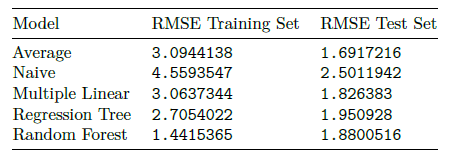

- The worst model is clearly the naive approach
- The linear model is more accurate than all but the average approach
- **This would suggest overfitting in the other models, with complexity not improving results**

## Graphical representation of residuals

[figure not shown]

## Accuracy in prediction of correct direction of price move

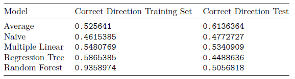

- Save for the average approach, the accuracy of price direction prediction is not significantly different from random
- Nevertheless, magnitude when correct is also important
- Looking at the algorithms again with a binary approach (positive or negative price change) could yield interesting results

## Conclusion

- **There is limited evidence that the non-price variables are helpful with the algorithms used to gain an edge in predicting prices versus a simple average approach**
- Overfitting is an issue, and doing further work with more data (perhaps on a lower timeframe) may improve the results
- We can however draw useful conclusions from the analysis performed:
- The distribution of returns suggests that a **mean-reverting trading strategy on SPY intra-week may work as weekly returns tend towards slightly above zero. Thus any intra-week deviation do not tend to last according to the distribution**
- **The price chart suggests that on higher timeframes there are clear trends where a trend-following approach may be work well**
- **Complex models without sufficient data or features that explain the dependent variable well do not trump simple approaches**

## Suggested Next Steps

- Review lower timeframes to test whether intra-week mean reversion approach has profit potential (taking into account trading costs)
- Perform analysis on higher timeframe to see whether variables have longer-term prediction power and whether long-term returns would father other types of trading strategies
- Develop a complete backtesting system that integrates code from the models developed to test profitability
- Look at more sophisticated algorithms, such as neural networks